# Epithelial: Label and coordinate transfer (validation cohort)

Ramon Massoni-Badosa

2023-06-01

# 1 Introduction

Here, we will transfer the label and UMAP coordinates from the discovery cohort to the validation cohort. We will do it one compartment at a time (here, follicular dendritic cells, epithelial), so we can validate that the transfer is robust.

Specifically, we will follow these steps for every compartment:

1. Include or update the annotation label for this object.
2. Plot the integrated object split by type (quey/reference) to visualize if discovery and validation cohorts were integrated properly.
3. Transfer label.
4. Transfer UMAP coordinates + visualize
5. Exclude cells with a low annotation probability and/or a high doublet score
6. Visualize heatmap of specific markers to validate that the cluster and annotation holds for the new cohort.

# 2 Pre-processing

## 2.1 Load packages

```r
library(Seurat)
library(tidyverse)
library(caret)
library(class)
library(harmony)
library(here)
library(glue)
library(DT)
```

## 2.2 Source functions

```r
source(here("scRNA-seq/bin/SLOcatoR_functions.R"))
source(here("scRNA-seq/bin/utils.R"))
source(here("scRNA-seq/bin/utils_final_clusters.R"))
color_palette <-  c("#1CFFCE", "#90AD1C", "#C075A6", "#85660D", "#5A5156", "#AA0DFE",
                    "#F8A19F", "#F7E1A0", "#1C8356", "#FEAF16", "#822E1C", "#C4451C",
                    "#1CBE4F", "#325A9B", "#F6222E", "#FE00FA", "#FBE426", "#16FF32",
                    "black",   "#3283FE", "#B00068", "#DEA0FD", "#B10DA1", "#E4E1E3",
                    "#90AD1C", "#FE00FA", "#85660D", "#3B00FB", "#822E1C", "coral2",
                    "#1CFFCE", "#1CBE4F", "#3283FE", "#FBE426", "#F7E1A0", "#325A9B",
                    "#2ED9FF", "#B5EFB5", "#5A5156", "#DEA0FD", "#FEAF16", "#683B79",
                    "#B10DA1", "#1C7F93", "#F8A19F", "dark orange", "#FEAF16", "#FBE426",
                    "Brown")
```

# 3 Epithelial

```r
# Read data, clean and include annotation
epithelial <- readRDS(here("scRNA-seq/results/R_objects/seurat_objects_revision/4.2-epithelial_seurat_object_discovery_validation_cohorts.rds"))
epithelial <- updateAnnotation(epithelial)
table(epithelial$assay)
```

```
##
##       3P multiome
##      396       97
```

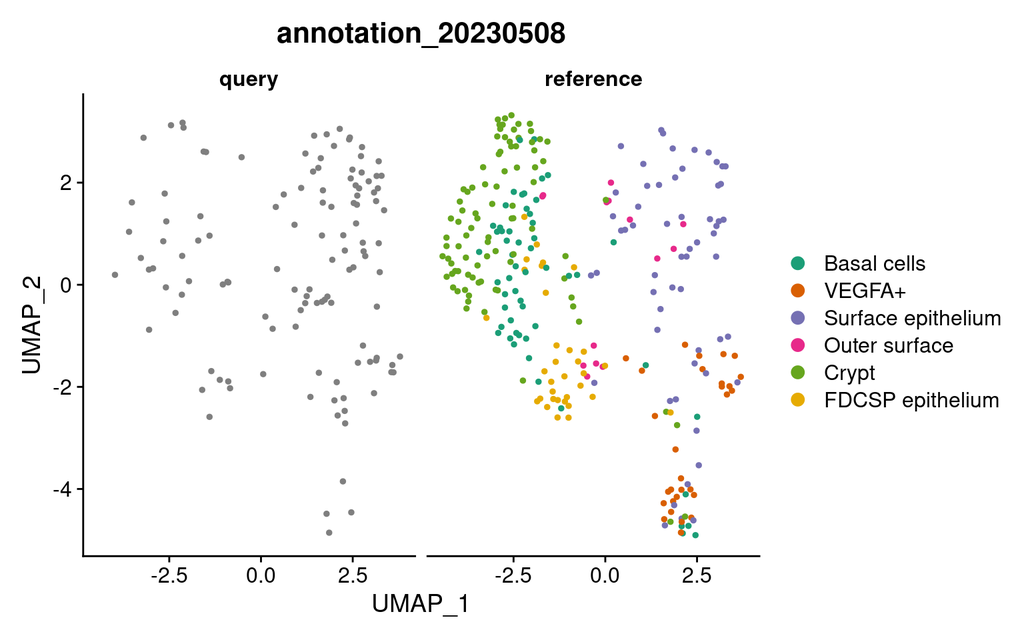

```r
epithelial <- epithelial[, epithelial$assay == "3P"]
epithelial$annotation_20230508 <- epithelial$annotation_20220619
epithelial$annotation_20230508[is.na(epithelial$annotation_20230508)] <- "unannotated"
epithelial$annotation_20230508 <- factor(
  epithelial$annotation_20230508,
  levels = names(colors_20230508[["epithelial"]])
)
Idents(epithelial) <- "annotation_20230508"
epithelial$is_reference <- ifelse(
  epithelial$cohort_type == "discovery",
  "reference",
  "query"
)
DimPlot(
  epithelial,
  group.by = "annotation_20230508",
  split.by = "is_reference",
  cols = colors_20230508[["epithelial"]]
)
```

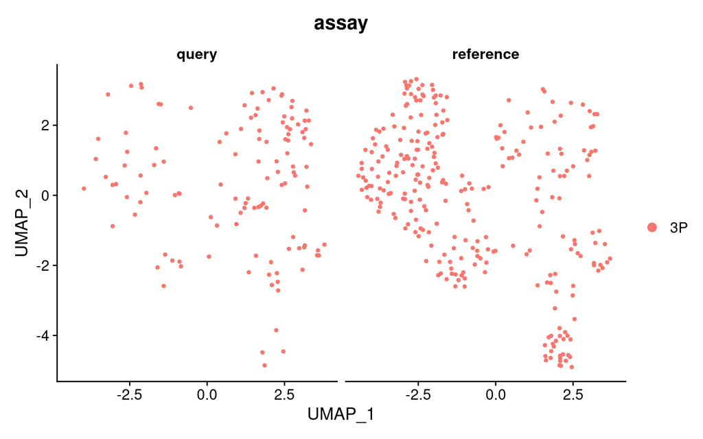

```r
DimPlot(
  epithelial,
  group.by = "assay",
  split.by = "is_reference"
)
```

We see that we have too few multiome cells for a proper label transfer. Thus, we will label them as “epithelial”, and focus on transering the label from the discovery scRNA-seq dataset to validation scRNA-seq. Let us integrate again this dataset:

```r
Idents(epithelial) <- "gem_id"
shared_hvg <- find_assay_specific_features(epithelial, assay_var = "cohort_type")
print(glue("The number of shared HVG is: {length(shared_hvg)}"))
```

```
## The number of shared HVG is: 1752
```

```r
table(epithelial$cohort_type)
```

```
##
##  discovery validation
##        277        119
```

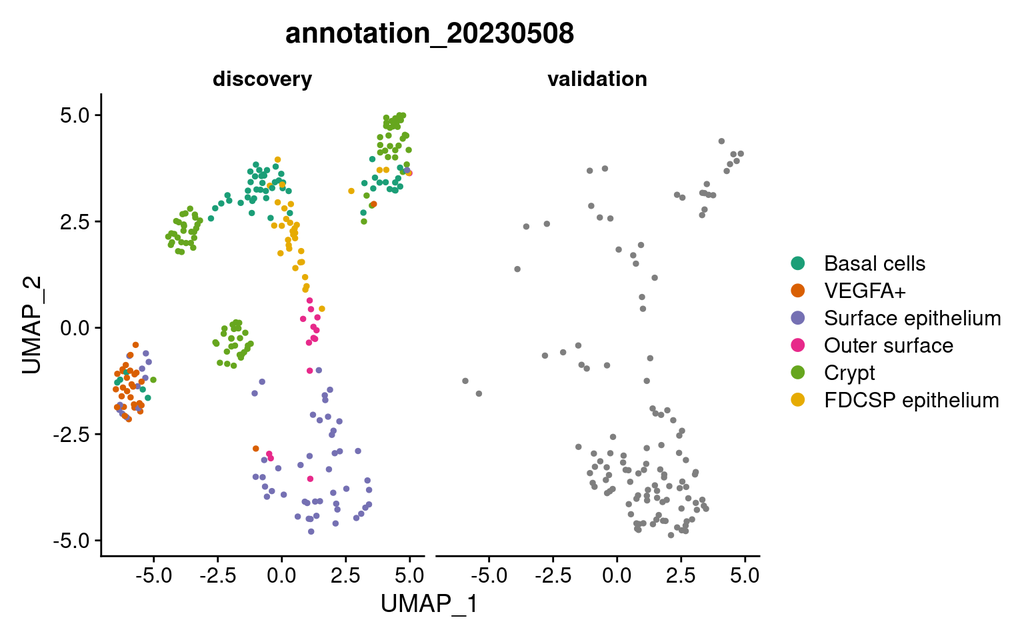

```r
epithelial <- integrate_assays(
  epithelial,
  assay_var = "cohort_type",
  shared_hvg = shared_hvg
)
epithelial <- RunUMAP(epithelial, dims = 1:25, reduction = "harmony")
DimPlot(
  epithelial,
  group.by = "annotation_20230508",
  split.by = "cohort_type",
  cols = colors_20230508[["epithelial"]]
)
```

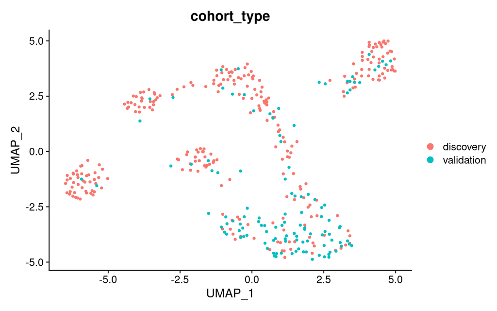

```r
DimPlot(
  epithelial,
  group.by = "cohort_type"
)
```

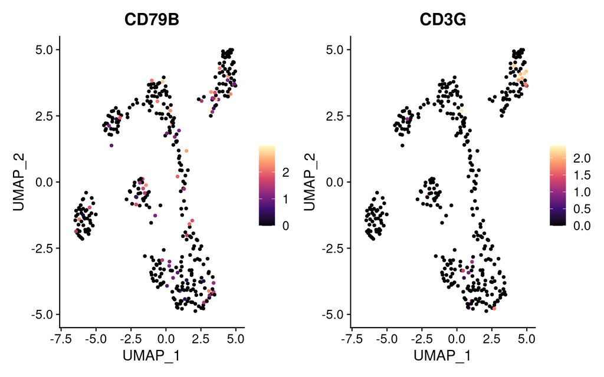

```r
FeaturePlot(epithelial, c("CD79B", "CD3G")) &
  scale_color_viridis_c(option = "magma")
```

Now we can transfer the label and UMAP coords

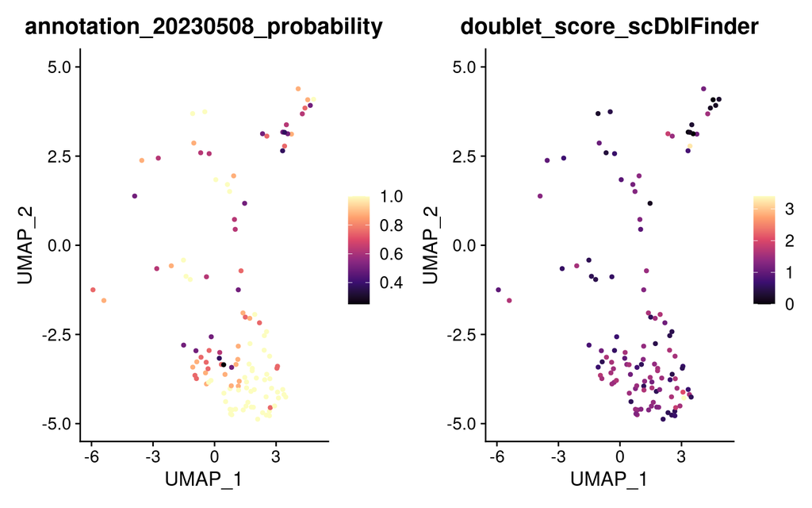

```r
# Split training and test sets
data_sets <- split_training_and_test_sets(
  epithelial,
  split_var = "cohort_type",
  referece_label = "discovery",
  query_label = "validation",
  reduction = "harmony",
  n_dims = 25
)

# Transfer label
annotation_query_df <- transfer_label(
  seurat_obj = epithelial,
  training_set = data_sets$training_set,
  test_set = data_sets$test_set,
  k = 8,
  response_var = "annotation_20230508"
)

# Transfer UMAP coords
# umap_test_df <- transfer_umap_coords(
#   seurat_obj = epithelial,
#   training_set = data_sets$training_set,
#   test_set = data_sets$test_set,
#   umap1_var = "UMAP_1_20220215",
#   umap2_var = "UMAP_2_20220215",
#   k = 15
# )


# Include annotation and UMAP coords in Seurat object
epithelial$annotation_20230508[annotation_query_df$query_cells] <- annotation_query_df$annotation
Idents(epithelial) <- "annotation_20230508"
epithelial$annotation_20230508_probability <- NA
epithelial$annotation_20230508_probability[annotation_query_df$query_cells] <- annotation_query_df$annotation_prob
# epithelial$UMAP_1_20220215[umap_test_df$query_cells] <- umap_test_df$UMAP1
# epithelial$UMAP_2_20220215[umap_test_df$query_cells] <- umap_test_df$UMAP2
p1 <- FeaturePlot(
  epithelial[, annotation_query_df$query_cells],
  "annotation_20230508_probability"
) + scale_color_viridis_c(option = "magma")
p2 <- FeaturePlot(
  epithelial[, annotation_query_df$query_cells],
  "doublet_score_scDblFinder"
) + scale_color_viridis_c(option = "magma")
p1 | p2
```

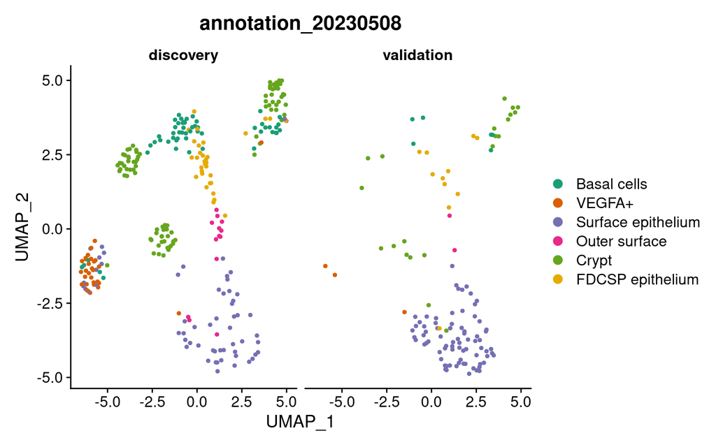

```r
DimPlot(
  epithelial,
  group.by = "annotation_20230508",
  split.by = "cohort_type",
  cols = colors_20230508[["epithelial"]]
)
```

```r
table(epithelial$annotation_20230508_probability)
```

```
##
##  0.25 0.375   0.5 0.625  0.75 0.875     1
##     1     3    11    10    17    21    56
```

Plot dot plot

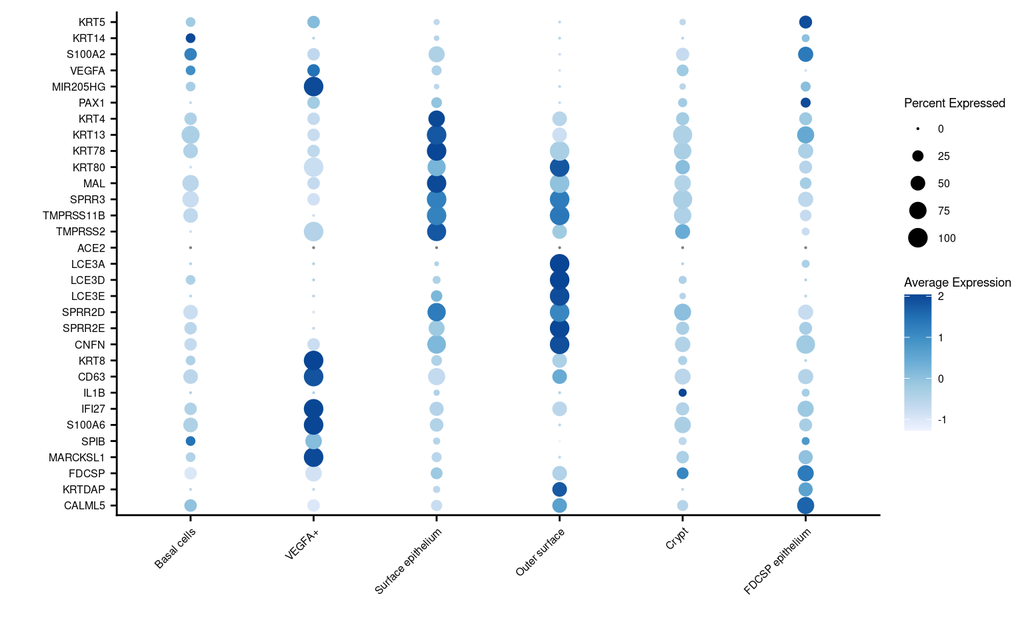

```r
goi_epithelial <- list(
  Basal_cells = c("KRT5", "KRT14", "S100A2"),
  VEGFA = c("VEGFA", "MIR205HG", "PAX1"),
  Surface_epithelium = c("KRT4", "KRT13", "KRT78", "KRT80", "MAL", "SPRR3", "TMPRSS11B", "TMPRSS2", "ACE2"),
  Outer_surface = c("LCE3A", "LCE3D", "LCE3E", "SPRR2D", "SPRR2E", "CNFN"),
  Crypt = c("KRT8", "CD63", "IL1B", "IFI27", "S100A6", "SPIB", "MARCKSL1"),
  FDCSP_epithelium = c("FDCSP", "KRTDAP", "CALML5")
)
goi_epithelial <- unlist(goi_epithelial)
names(goi_epithelial) <- NULL
dot_plot_epi <- DotPlot(
  epithelial[, epithelial$cohort_type == "validation"],
  features = rev(goi_epithelial),
  group.by = "annotation_20230508"
)
dot_plot_epi <- dot_plot_epi +
  labs(x = "", y = "") +
  scale_size_continuous(
    limits = c(0, 100),
    breaks = c(0, 25, 50, 75, 100),
    range = c(0.1, 4.5)
  ) +
  scale_color_distiller(palette = "Blues", direction = 1) +
  coord_flip() +
  theme(
    axis.text.x = element_text(angle = 45, hjust = 1, vjust = 1, size = 6),
    axis.text.y = element_text(size = 6),
    legend.text = element_text(size = 6),
    legend.title = element_text(size = 7)
  )
dot_plot_epi
```

# 4 Save

```r
saveRDS(epithelial, here("scRNA-seq/results/R_objects/seurat_objects_revision/5.2-epithelial_seurat_object_discovery_validation_cohorts_annotation.rds"))
```